# Reproducible Research: Peer Assessment 1

Wicitra Mahotama

June 25, 2016

## Loading and preprocessing the data

```r
raw <- read.csv("activity.csv")
```

## What is the mean total number of steps taken per day?

Calculate the total number of steps taken per day.

```r
steps.day <- aggregate(data=raw,steps~date,sum)
print(steps.day)
```

```
##          date steps
## 1  2012-10-02   126
## 2  2012-10-03 11352
## 3  2012-10-04 12116
## 4  2012-10-05 13294
## 5  2012-10-06 15420
## 6  2012-10-07 11015
## 7  2012-10-09 12811
## 8  2012-10-10  9900
## 9  2012-10-11 10304
## 10 2012-10-12 17382
## 11 2012-10-13 12426
## 12 2012-10-14 15098
## 13 2012-10-15 10139
## 14 2012-10-16 15084
```

[output cut: 39 more lines]

Make a histogram of the total number of steps taken each day

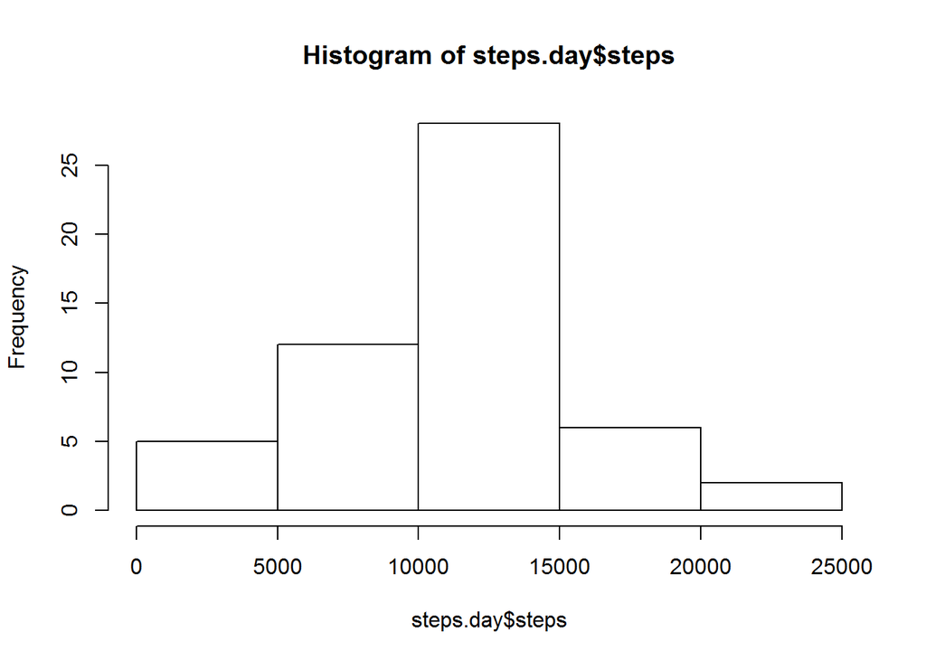

```r
hist(steps.day$steps)
```

Calculate and report the mean and median of the total number of steps taken per day

```r
steps.mean <- mean(steps.day$steps)
print(steps.mean)
```

```
## [1] 10766.19
```

```r
steps.median <- median(steps.day$steps)
print(steps.median)
```

```
## [1] 10765
```

## What is the average daily activity pattern?

Make a time series plot (i.e. type = “l”) of the 5-minute interval (x-axis) and the average number of steps taken, averaged across all days (y-axis)

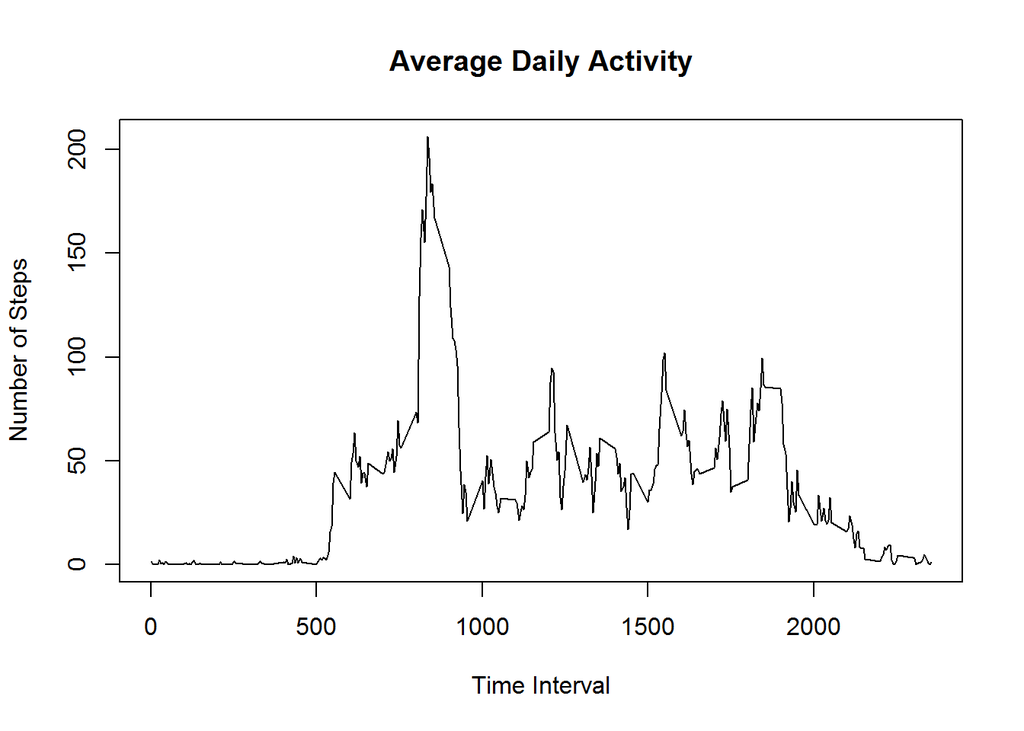

```r
steps.interval <- aggregate(data = raw, steps~interval,mean)
plot(steps.interval$interval,steps.interval$steps, type = "l", xlab = "Time Interval", ylab = "Number of Steps", main = "Average Daily Activity")
```

Which 5-minute interval, on average across all the days in the dataset, contains the maximum number of steps?

```r
max.step <- max(steps.interval$steps)
max.interval <- subset(steps.interval, steps == max.step)
print(max.interval)
```

```
##     interval    steps
## 104      835 206.1698
```

## Imputing missing values

Calculate and report the total number of missing values in the dataset (i.e. the total number of rows with NAs)

```r
sum(!complete.cases(raw))
```

```
## [1] 2304
```

Replace NA values with the average number of steps based on the interval at which the NA value occurs.

```r
test <- is.na(raw$steps)
yes <- steps.interval$steps[match(raw$interval,steps.interval$interval)]
no <- raw$steps

steps.imputed <- ifelse(test,yes,no)
```

Create a new dataset that is equal to the original dataset but with the missing data filled in.

```r
data.imputed <- transform(raw,steps = steps.imputed)
```

Make a histogram of the total number of steps taken each day and Calculate and report the mean and median total number of steps taken per day.

Calculate the total number of steps taken per day.

```r
steps.day.imputed <- aggregate(data=data.imputed,steps~date,sum)
print(steps.day.imputed)
```

```
##          date    steps
## 1  2012-10-01 10766.19
## 2  2012-10-02   126.00
## 3  2012-10-03 11352.00
## 4  2012-10-04 12116.00
## 5  2012-10-05 13294.00
## 6  2012-10-06 15420.00
## 7  2012-10-07 11015.00
## 8  2012-10-08 10766.19
## 9  2012-10-09 12811.00
## 10 2012-10-10  9900.00
## 11 2012-10-11 10304.00
## 12 2012-10-12 17382.00
## 13 2012-10-13 12426.00
## 14 2012-10-14 15098.00
```

[output cut: 47 more lines]

Calculate and report the mean and median of the total number of steps taken per day

```r
steps.mean.imputed <- mean(steps.day.imputed$steps)
print(steps.mean.imputed)
```

```
## [1] 10766.19
```

```r
steps.median.imputed <- median(steps.day.imputed$steps)
print(steps.median.imputed)
```

```
## [1] 10766.19
```

Make a histogram of the total number of steps taken each day

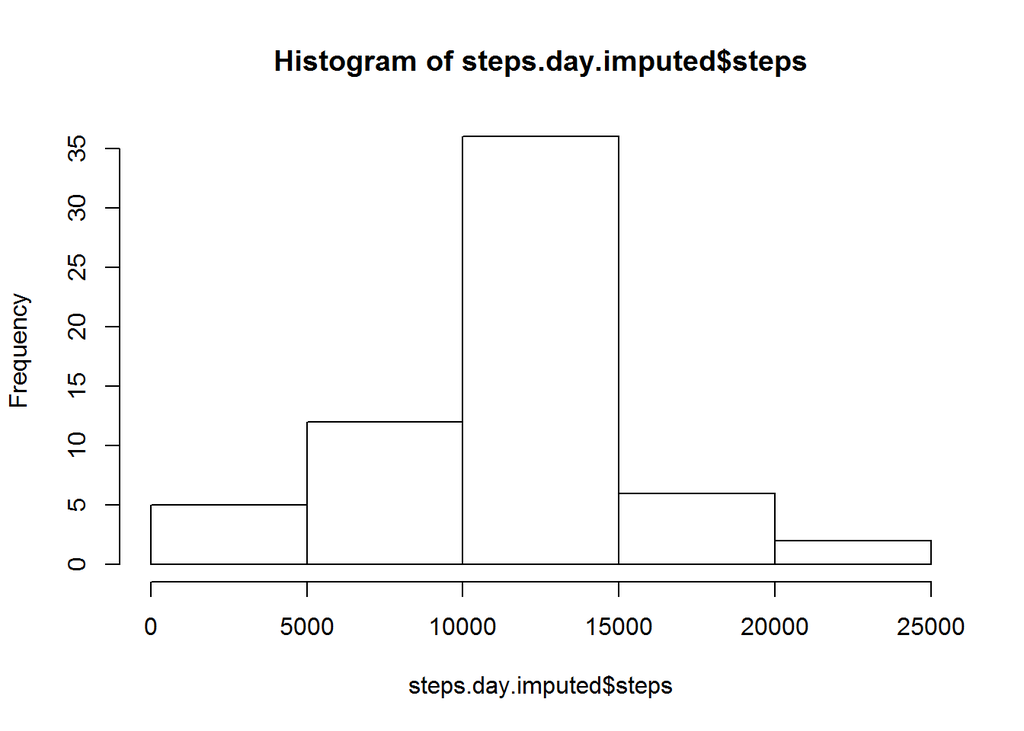

```r
hist(steps.day.imputed$steps)
```

What is the impact of imputing missing data on the estimates of the total daily number of steps? Imputing the missing data on the estimates of the total daily number of steps increases the median to equal the mean.

## Are there differences in activity patterns between weekdays and weekends?

Create a new column to store the day of the week.

```r
data.imputed$day <- weekdays(as.Date(data.imputed$date))
```

Create a new column which classifies the day of the week into two categories, weekday or weekend.

```r
weekday <- c("Monday","Tuesday","Wednesday","Thursday","Friday")
classification <- ifelse(is.element(data.imputed$day,weekday),"Weekday","Weekend")
data.imputed$dow <- as.factor(classification)
```

Subset data by weekend and weekday classification

```r
weekday.data <- subset(data.imputed, dow == "Weekday")
weekend.data <- subset(data.imputed, dow == "Weekend")

str(weekday.data)
```

```
## 'data.frame':    12960 obs. of  5 variables:
##  $ steps   : num  1.717 0.3396 0.1321 0.1509 0.0755 ...
##  $ date    : Factor w/ 61 levels "2012-10-01","2012-10-02",..: 1 1 1 1 1 1 1 1 1 1 ...
##  $ interval: int  0 5 10 15 20 25 30 35 40 45 ...
##  $ day     : chr  "Monday" "Monday" "Monday" "Monday" ...
##  $ dow     : Factor w/ 2 levels "Weekday","Weekend": 1 1 1 1 1 1 1 1 1 1 ...
```

```r
str(weekend.data)
```

```
## 'data.frame':    4608 obs. of  5 variables:
##  $ steps   : num  0 0 0 0 0 0 0 0 0 0 ...
##  $ date    : Factor w/ 61 levels "2012-10-01","2012-10-02",..: 6 6 6 6 6 6 6 6 6 6 ...
##  $ interval: int  0 5 10 15 20 25 30 35 40 45 ...
##  $ day     : chr  "Saturday" "Saturday" "Saturday" "Saturday" ...
##  $ dow     : Factor w/ 2 levels "Weekday","Weekend": 2 2 2 2 2 2 2 2 2 2 ...
```

Calculate the activity patterns during the weekdays and weekends

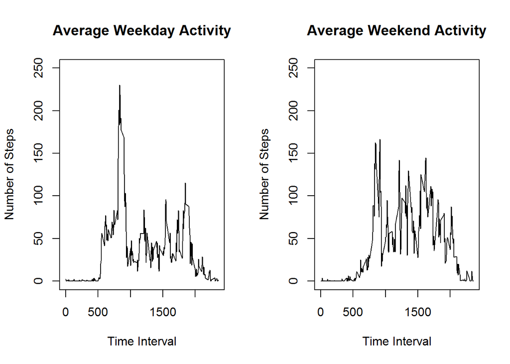

```r
par(mfrow=c(1,2))

weekday.activity <- aggregate(data = weekday.data, steps~interval,mean)
weekday.plot <- plot(weekday.activity$interval,weekday.activity$steps, xlab = "Time Interval", ylab = "Number of Steps", ylim = c(0,250), main = "Average Weekday Activity", type = "l")

weekend.activity <- aggregate(data = weekend.data, steps~interval,mean)
weekend.plot <- plot(weekend.activity$interval,weekend.activity$steps, xlab = "Time Interval", ylab = "Number of Steps", ylim = c(0,250), main = "Average Weekend Activity", type = "l")
```